# Playing with Arabian Nights

2023-08-24

# Textmining in The Arabian Nights

This script combines code I shared with students in Digital Methods course and a corpus of Arabian Nights selected by one of the 2022 cohort (Laura Jensen) for her text-mining project.

First you will need to install/have the following packages:

```r
knitr::opts_chunk$set(echo = TRUE)

library(tidyverse)
library(here)
```

```r
library(tidytext)
library(textdata)
library(ggwordcloud)
```

## Load the data

The text of the Arabian Nights was downloaded from the Gutenberg project using the `gutenbergr` package in script 08b-text-download.R, and then saved as .rds dataset. We now load that dataset into R memory.

```r
an_df <- readRDS("data/arabian.rds")
```

In the dataframe there is a lot of text, that aren’t part of the stories that are Arabian Nights. To get the most accurate result we will trim most of the excessive text away by specific rows:

```r
an_df_tidy <- an_df[-c(1:780, 1545:1844, 2268:2437, 3866:4536, 7995:9555, 9846:9913, 11869:12845, 15962:18806, 151902:189676, 148281:150158, 131077:133627, 114421:116373, 97810:99392, 83707:85877, 65031:66536, 48903:51794),]
```

Let’s figure out the frequency of words in Arabian Nights. The first thing we have to do is to tokenize the dataframe, so that every word gets it’s own row in a dataframe:

```r
an_tokens <- an_df_tidy %>%
  unnest_tokens(word, text)
```

Now we can count how many there are of each word, and sort them after the most frequent one:

```r
an_wc <- an_tokens %>%
  count(word) %>%
  arrange(-n)
an_wc %>% slice(1:100)%>% pull(word)
```

```
##   [1] "and"      "the"      "of"       "to"       "he"       "a"
##   [7] "i"        "in"       "him"      "his"      "with"     "her"
##  [13] "my"       "it"       "me"       "for"      "that"     "is"
##  [19] "she"      "thou"     "this"     "was"      "said"     "thee"
##  [25] "when"     "so"       "o"        "they"     "but"      "not"
##  [31] "on"       "them"     "by"       "from"     "as"       "thy"
##  [37] "then"     "who"      "be"       "had"      "al"       "all"
##  [43] "king"     "which"    "will"     "at"       "what"     "allah"
##  [49] "have"     "one"      "we"       "till"     "hath"     "now"
##  [55] "footnote" "day"      "their"    "out"      "came"     "night"
##  [61] "an"       "there"    "quoth"    "upon"     "no"       "up"
##  [67] "or"       "us"       "were"     "saying"   "after"    "say"
##  [73] "went"     "man"      "are"      "these"    "down"     "shall"
##  [79] "do"       "like"     "son"      "before"   "saw"      "made"
##  [85] "answered" "if"       "took"     "our"      "two"      "would"
##  [91] "how"      "nor"      "replied"  "into"     "love"     "come"
##  [97] "ceased"   "where"    "may"      "heard"
```

Then we can add the stopwords list:

```r
an_stop <- an_tokens %>%
  anti_join(stop_words)
```

Then we count and sort the words again:

```r
an_swc <- an_stop %>%
  count(word) %>%
  arrange(-n)
an_swc %>% slice(1:100)%>% pull(word)
```

```
##   [1] "thou"       "thee"       "thy"        "al"         "king"
##   [6] "allah"      "till"       "hath"       "footnote"   "day"
##  [11] "night"      "quoth"      "son"        "answered"   "replied"
##  [16] "love"       "ceased"     "heard"      "hundred"    "lord"
##  [21] "heart"      "set"        "reached"    "hand"       "found"
##  [26] "house"      "city"       "head"       "dawn"       "time"
##  [31] "hast"       "wazir"      "brought"    "art"        "father"
##  [36] "cried"      "fell"       "eyes"       "arab"       "auspicious"
##  [41] "shahrazad"  "caliph"     "left"       "days"       "perceived"
##  [46] "permitted"  "brother"    "life"       "words"      "lady"
##  [51] "woman"      "returned"   "told"       "sat"        "wife"
##  [56] "save"       "whilst"     "rose"       "thousand"   "daughter"
##  [61] "bring"      "ye"         "called"     "presently"  "door"
##  [66] "gold"       "thine"      "slave"      "folk"       "bade"
##  [71] "palace"     "hands"      "mother"     "wilt"       "leave"
##  [76] "din"        "water"      "death"      "return"     "fear"
##  [81] "behold"     "land"       "hasan"      "entered"    "abu"
##  [86] "couplets"   "almighty"   "dinars"     "ali"        "sight"
##  [91] "tale"       "people"     "joy"        "world"      "youth"
##  [96] "women"      "sea"        "girl"       "prince"     "damsel"
```

Because the translation dates to the 19th century, there are a lot of old words that are not in the stopword list, but should still be removed for practicality’s sake. Therefore we should create an additional stopword list:

```r
my_stop_words <- data.frame(word = c("thou", "thee", "thy", "till", "hath", "quoth", "footnote", "answered", "replied", "set", "al", "arab", "ye"))
```

Now we use the newly created stopword list to remove the extra words from our an_df_tidy dataframe:

```r
an_stop_new <- an_stop %>%
  anti_join(my_stop_words)
```

Then we count and sort the words again:

```r
an_stop_new %>%
  count(word) %>%
  arrange(-n)
```

```
## # A tibble: 33,991 × 2
##    word        n
##    <chr>   <int>
##  1 king     4953
##  2 allah    4219
##  3 day      3199
##  4 night    2962
##  5 son      2102
##  6 love     1653
##  7 ceased   1641
##  8 heard    1595
##  9 hundred  1574
## 10 lord     1564
## # … with 33,981 more rows
```

### Wordcloud

Let’s now make a wordcloud with the most frequent words in Arabian Nights. The first thing we want to do is to filter out any numbers from the text:

```r
an_no_numeric <- an_stop_new %>%
  filter(is.na(as.numeric(word)))
length(unique(an_no_numeric$word))
```

```
## [1] 33123
```

By using this code we can see that there are over 33.000 unique words in Arabian Nights. That is too many to fit into one wordcloud, so we want to limit the number of words in the wordcloud to the most frequent100.

To limit the number of words in the wordcloud, do this:

```r
an_top100 <- an_no_numeric %>%
  count(word) %>%
  arrange(-n) %>%
  head(100)
```

Now we make a wordcloud based on the new dataframe, we just created, with only the 100 most frequent words in Arabian Nights:

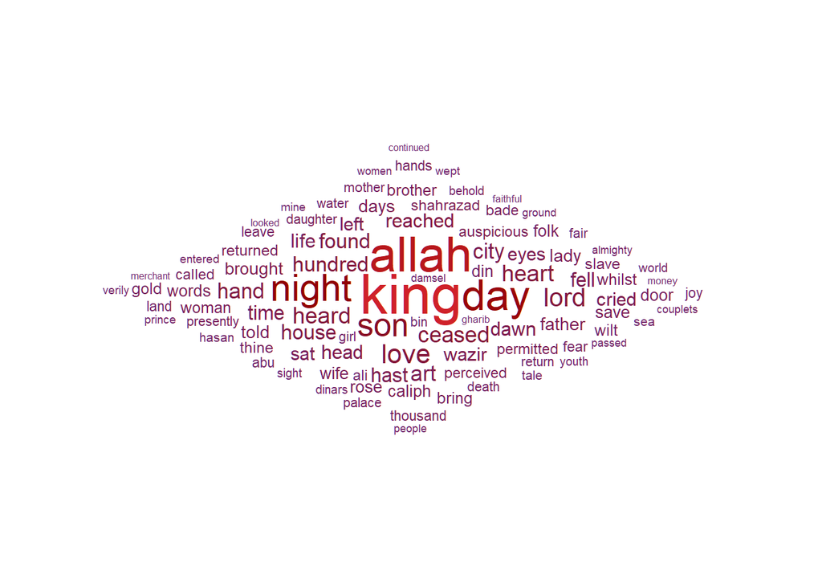

```r
ggplot(data = an_top100, aes(label = word, size = n)) +
  geom_text_wordcloud_area(aes(color = n), shape = "diamond") +
  scale_size_area(max_size = 12) +
  scale_color_gradientn(colors = c("#72286F","darkred","#CF2129")) +
  theme_minimal()
```

I can then see that the most frequent word is “king”, but it is worth noting that words like “love” and “wife” also is on the list of the 100 most frequent words in Arabian Nights, and that is words that would be interesting to take a little closer look at.

### Sentiment Analysis

First we’ll do a sentiment analysis on Arabian Nights. We focus on the ten main emotions in the “nrc” lexicon, which we have to load first:

```r
get_sentiments(lexicon = "nrc")
```

```
## # A tibble: 13,872 × 2
##    word        sentiment
##    <chr>       <chr>
##  1 abacus      trust
##  2 abandon     fear
##  3 abandon     negative
##  4 abandon     sadness
##  5 abandoned   anger
##  6 abandoned   fear
##  7 abandoned   negative
##  8 abandoned   sadness
##  9 abandonment anger
## 10 abandonment fear
## # … with 13,862 more rows
```

**Citation for NRC lexicon**: Crowdsourcing a Word-Emotion Association Lexicon, Saif Mohammad and Peter Turney, Computational Intelligence, 29 (3), 436-465, 2013.

Then we’ll create a new dataframe where we add the lexicon to my existing dataframe:

```r
an_nrc <- an_stop_new %>%
  inner_join(get_sentiments("nrc"))
```

By binding the lexicon to the dataframe, we exclude words, that don’t have a “sentiment” value. It is smart to just have a look at which words are excluded:

```r
an_exclude <- an_stop_new %>%
  anti_join(get_sentiments("nrc"))
an_exclude_n <- an_exclude %>%
  count(word, sort = TRUE)

head(an_exclude_n)
```

```
## # A tibble: 6 × 2
##   word       n
##   <chr>  <int>
## 1 allah   4219
## 2 day     3199
## 3 night   2962
## 4 son     2102
## 5 ceased  1641
## 6 heard   1595
```

It is interesting that a word like “allah” has been excluded, you would think that it has a “sentiment” value.

Now we count how many words fit into each of the 10 different “sentiment” categories, and then we plot them:

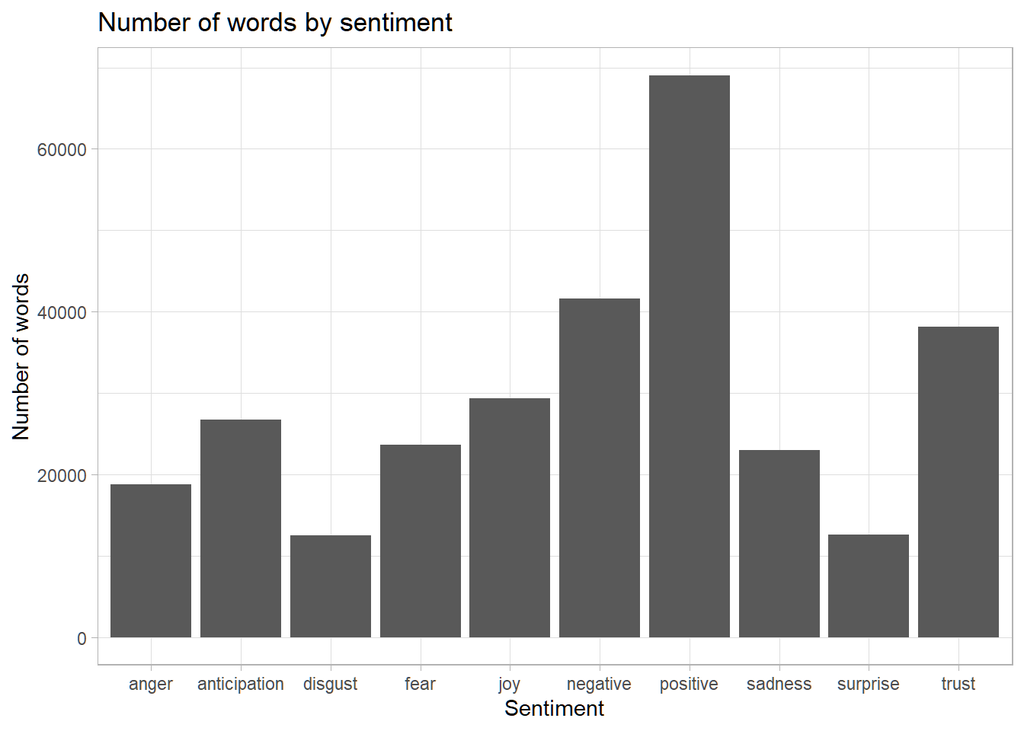

```r
an_nrc_n <- an_nrc %>%
  count(sentiment, sort = TRUE)

ggplot(data = an_nrc_n, aes(x = sentiment, y = n)) +
  geom_bar(stat = "identity",
           #color = "darkred",
           #fill = "#D60103"
           ) +
  theme_light() +
  ggtitle("Number of words by sentiment") +
  xlab("Sentiment") + ylab("Number of words")
```

From this we can see that there are a lot of words that are of a positive “sentiment”.

Since we are interested in words like “love” and others that are related to it, let’s look which “sentiment” categories that the word “love” is in:

```r
love <- get_sentiments(lexicon = "nrc") %>%
  filter(word == "love", ignore_case = TRUE)

love
```

```
## # A tibble: 2 × 2
##   word  sentiment
##   <chr> <chr>
## 1 love  joy
## 2 love  positive
```

I can now see that the word “love” is both in the category of “joy” and “positive”. Therefore we want to take a closer look at those two categories, to see which other words are in them, and if they are relevant for my project. We focus on “joy” first:

The first step is to create a new dataframe that only contains the words in the “joy” category:

```r
nrc_joy <- get_sentiments("nrc") %>%
  filter(sentiment == "joy")
```

Then we count the words, and sort them by most frequent. we also limit them to only the 15 most frequent. We then plot those 15 words, and order them by frequency:

```r
nrc_joy_sort <- an_stop_new %>%
  inner_join(nrc_joy) %>%
  count(word, sort = TRUE) %>%
  head(15)
```

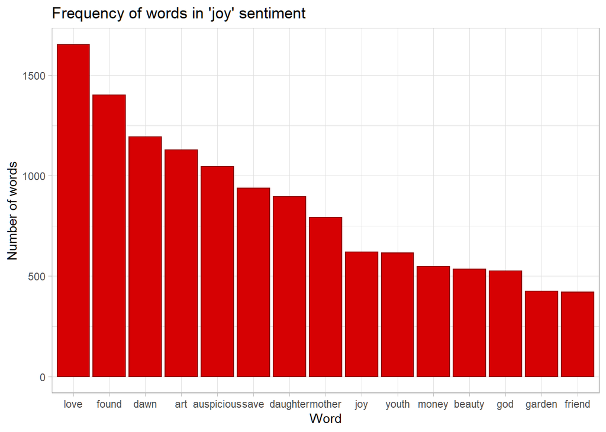

```r
ggplot(data = nrc_joy_sort, aes(x = reorder(word, -n), y = n)) +
  geom_bar(stat = "identity", color = "darkred", fill = "#D60103") +
  theme_light() +
  ggtitle("Frequency of words in 'joy' sentiment") +
  xlab("Word") + ylab("Number of words")
```

It’s interesting to see, that apart from “love”, words like “youth” and “beauty” are also relatively frequent.

Now we do the same for the category “positive”. We first create a new dataframe:

```r
nrc_positive <- get_sentiments("nrc") %>%
  filter(sentiment == "positive")
```

Then we count the words, and sort them by most frequent. We also limit the plot to the 15 most frequent ones:

```r
nrc_positive_sort <- an_stop_new %>%
  inner_join(nrc_positive) %>%
  count(word, sort = TRUE) %>%
  head(15)
```

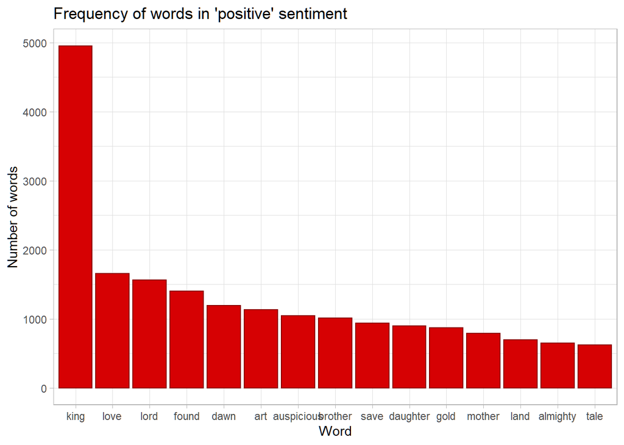

```r
ggplot(data = nrc_positive_sort, aes(x = reorder(word, -n), y = n)) +
  geom_bar(stat = "identity", color = "darkred", fill = "#D60103") +
  theme_light() +
  ggtitle("Frequency of words in 'positive' sentiment") +
  xlab("Word") + ylab("Number of words")
```

Here we can see, that the word “king” is much more frequent than any of the other positive words.

### Word frequency by night

Now we take a look at which stories the words such as love and marriage occur most frequently in. This can help us focus on reading the most relevant tales:

First, we want to split the book up into smaller sections, to get the most precise results, when we look for where in Arabian Nights we can find a high frequency of words. Ideally, we would have split up the book by separate tales, but finding a regex for that is a bit complex, and so we instead split it by separate nights, this way:

```r
an_df_tidy %>%
  mutate(
    linenumber = row_number()) %>%
  filter(str_detect(text, regex("Now when it w*as the .+ Night", ignore_case = TRUE)))
```

```
## # A tibble: 1,000 × 3
##    gutenberg_id text                                                     linen…¹
##           <int> <chr>                                                      <int>
##  1        51252 "                    Now when it was the Second Night,"      923
##  2        51252 "                    Now when it was the Third Night,"      1174
##  3        51252 "                    Now when it was the Fourth Night,"     1388
##  4        51252 "                    Now when it was the Fifth Night,"      1598
##  5        51252 "                    Now when it was the Sixth Night,"      1947
##  6        51252 "                   Now when it was the Seventh Night,"     2084
##  7        51252 "                    Now when it was the Eighth Night,"     2351
##  8        51252 "                    Now when it was the Ninth Night,"      2553
##  9        51252 "                    Now when it was the Tenth Night,"      2975
## 10        51252 "                   Now when it was the Eleventh Night,"    3337
## # … with 990 more rows, and abbreviated variable name ¹linenumber
```

When you run this, you should get a tibble, that has a 1000 rows. we can only capture 1000 nights, since the first night isn’t written out, so it is as close as we can get.

We now make it into a new dataframe, where each night has a number associated with it:

```r
tidy_stories <- an_df_tidy %>%
  mutate(linenumber = row_number(), chapter = cumsum(str_detect(text, regex("Now when it w*as the .+ Night", ignore_case = TRUE))))
```

It is important to note that the first story has the number “0” and the second story has the number “1” and so on. Therefore to get the correct night, you have to take the number you get in the code, and add 1 to it. When we find out which nights the words are most frequent in, then we can look up which story the night belongs to, and then read it. we can find a list over stories, with night numbers here: https://en.wikipedia.org/wiki/List_of_stories_within_One_Thousand_and_One_Nights

```r
tidy_love <- tidy_stories %>%
  filter(str_detect(text, regex("love", ignore_case = TRUE))) %>%
  count(chapter, sort = TRUE) %>%
  head(20)
```

Then plot the result:

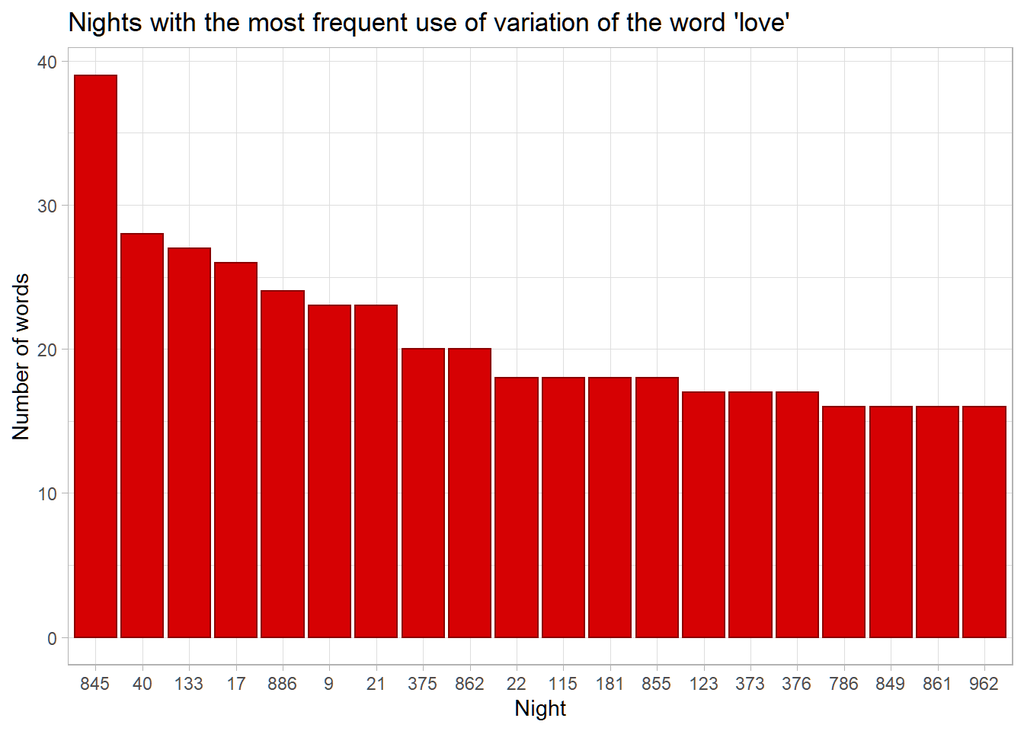

```r
tidy_love %>%
  ggplot(aes(x = reorder(chapter, -n), y = n)) +
  geom_bar(stat = "identity", color = "darkred", fill = "#D60103") +
  theme_light() +
  ggtitle("Nights with the most frequent use of variation of the word 'love'") +
  xlab("Night") + ylab("Number of words")
```

```r
tidy_stories %>%
  filter(chapter == 845)
```

```
## # A tibble: 436 × 4
##    gutenberg_id text                                             linen…¹ chapter
##           <int> <chr>                                              <int>   <int>
##  1        55091 "        Now when it was the Eight Hundred and …  107877     845
##  2        55091 ""                                                107878     845
##  3        55091 "She continued, It hath reached me, O auspiciou…  107879     845
##  4        55091 "merchant awoke, he strave with his yearnings t…  107880     845
##  5        55091 "to himself, “There is no help but that I go th…  107881     845
##  6        55091 "will expound to me this vision.” So he went fo…  107882     845
##  7        55091 "left, till he was far from his dwelling-place,…  107883     845
##  8        55091 "interpret the dream to him. Then he would have…  107884     845
##  9        55091 "behold, the fancy took him to turn aside to th…  107885     845
## 10        55091 "trader, a man of the wealthiest, and when he d…  107886     845
## # … with 426 more rows, and abbreviated variable name ¹linenumber
```

Here we can see that night 846, is the night where there is the most frequent use of the word “love”. That is the tale of Masrur and Zayn Al-Mawasif.

Another word, or variations of a word, that we can look at is “marr” for marriage. Let’s repeat the two previous steps and replace “love” with “marr”.

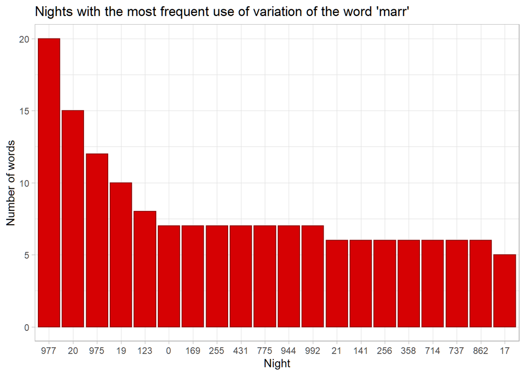

```r
tidy_marr <- tidy_stories %>%
  filter(str_detect(text, regex("marr", ignore_case = TRUE))) %>%
  count(chapter, sort = TRUE) %>%
  head(20)

tidy_marr %>%
  ggplot(aes(x = reorder(chapter, -n), y = n)) +
  geom_bar(stat = "identity", color = "darkred", fill = "#D60103") +
  theme_light() +
  ggtitle("Nights with the most frequent use of variation of the word 'marr'") +
  xlab("Night") + ylab("Number of words")
```

### Term frequency analysis (tdf-idf)

Looking at the frequency of a single word in different sections of a book is one way to look at word frequency, but such frequency can be skewed by the length and diversity of words used within each section. It is therefore more cautious to look at the number of one specific word in relation to the total number of words in one night. To do that we have to do a term frequency analysis, which is explained here: https://www.tidytextmining.com/tfidf.html

The first step is to once again tokenize the dataframe. This time we tokenize the dataframe, where each night/tale also gets a number assigned to it. We also count all the words, but this time they are split by night number(tale).

```r
tidy_stories_untoken <- tidy_stories %>%
  unnest_tokens(word, text) %>%
  count(chapter, word, sort = TRUE)
```

Then we count how many words are in each night(chapter)

```r
total_words_stories <- tidy_stories_untoken%>%
  group_by(chapter) %>%
  summarize(total = sum(n))
```

Then we join those different counts in to a new dataframe, that then contains “chapter”, “word”, “n” and “total”

```r
chapter_words <- left_join(tidy_stories_untoken, total_words_stories)
```

Lastly we want to calculate the percentage of target words in a night. We do that by filtering the target word, then by using the mutate() function to create a new column where we calculate the frequency of a word in percent. By arranging the rows based on frequency, we can then see which night has the highest percentage of target words in relation to total words:

```r
chapter_words %>%
  filter(str_detect(word, regex("love", ignore_case = TRUE))) %>%
  mutate(frequency =((n/total)*100)) %>%
  arrange(desc(frequency))
```

```
## # A tibble: 1,583 × 5
##    chapter word        n total frequency
##      <int> <chr>   <int> <int>     <dbl>
##  1     855 love       17  1131     1.50
##  2     860 love        9   610     1.48
##  3     180 love        8   628     1.27
##  4     861 love       12  1035     1.16
##  5     786 love       14  1225     1.14
##  6     371 love       10   881     1.14
##  7     179 beloved     8   739     1.08
##  8     196 love        6   572     1.05
##  9     886 love       17  1663     1.02
## 10     373 love       11  1111     0.990
## # … with 1,573 more rows
```

In this way we can see that the night, which has the most words being “love” in relation to the total number of words in the night is 856.

### If a word appears

It would also be interesting to have a look at the word “sex”. Does it even appear in Arabian Nights?:

```r
tidy_stories %>%
  filter(str_detect(text, regex("sex", ignore_case = TRUE)))
```

```
## # A tibble: 31 × 4
##    gutenberg_id text                                             linen…¹ chapter
##           <int> <chr>                                              <int>   <int>
##  1        51252 " say which be the better and the nicer, mine o…    7955      23
##  2        51775 "  Arab. \"Farj\"; hence a facetious designatio…   14599      44
##  3        51775 "neither accost one of our sex, be she young or…   23180     119
##  4        51775 "  societies where the sexes are separated spee…   23708     123
##  5        51775 "  beauty or conditions of the \"veiled sex.\" …   24704     123
##  6        51775 "  and pronounced so by Egyptians. It is worn b…   25006     123
##  7        51775 "  women prefer their own sex. These tribades a…   25364     123
##  8        51775 "  the law of unlikeness which mostly governs s…   25834     123
##  9        52564 "with any of her sex. Know that she who wrought…   27981     127
## 10        52564 "and proportions strongly excited her desires s…   29048     133
## # … with 21 more rows, and abbreviated variable name ¹linenumber
```

Now that we see the context of “sex”, we see that it mainly appears in the relation to gender and in some of the footnotes we haven’t been able to trim away.

A word that is often used as a metaphor for sex and the woman’s body is “pomegranate”. Let’s look where that appears in the Arabian Nights:

```r
tidy_stories %>%
  filter(str_detect(text, regex("pomegranate", ignore_case = TRUE)))
```

```
## # A tibble: 68 × 4
##    gutenberg_id text                                             linen…¹ chapter
##           <int> <chr>                                              <int>   <int>
##  1        51252 " pomegranate-bloom, eglantine and narcissus, a…    2644       8
##  2        51252 " pomegranates of even size, stood at bay as it…    2689       8
##  3        51252 " and crept into a huge red pomegranate,[250] w…    4346      13
##  4        51252 " pomegranate swelled to the size of a water-me…    4348      13
##  5        51252 " beginning. I had no trouble till the time whe…    4404      13
##  6        51252 "    its leafy screen pomegranate hides from si…    7160      21
##  7        51252 " He had just dressed a conserve of pomegranate…    7643      22
##  8        51252 " ladled into a saucer some conserve of pomegra…    7676      22
##  9        51252 " confection of pomegranate-grains. When the tw…    7836      22
## 10        51252 " pomegranate-grains. Said Ajib, \"Sit thee dow…    7865      22
## # … with 58 more rows, and abbreviated variable name ¹linenumber
```

From this we can see that the word “pomegranate” shows up in the Arabian Nights sixty-eight times in different contexts. The contexts mostly seem non-sexual, but there are definitely some examples of using it as sexual metaphors, eg. row 31, 38, etc..

### Pomegranate Bigrams

```r
an_bigrams <- tidy_stories %>%
  unnest_tokens(bigram, text, token = "ngrams", n = 2) %>%
  filter(!is.na(bigram))

an_trigrams <- tidy_stories %>%
  unnest_tokens(trigram, text, token = "ngrams", n = 3) %>%
  filter(!is.na(trigram))

an_trigrams %>%
  filter(str_detect(trigram, regex("pomegranate", ignore_case = TRUE)))
```

```
## # A tibble: 155 × 4
##    gutenberg_id linenumber chapter trigram
##           <int>      <int>   <int> <chr>
##  1        51252       2644       8 pomegranate bloom eglantine
##  2        51252       2689       8 pomegranates of even
##  3        51252       4346      13 huge red pomegranate
##  4        51252       4346      13 red pomegranate 250
##  5        51252       4346      13 pomegranate 250 which
##  6        51252       4348      13 pomegranate swelled to
##  7        51252       4404      13 when the pomegranate
##  8        51252       4404      13 the pomegranate burst
##  9        51252       7160      21 leafy screen pomegranate
## 10        51252       7160      21 screen pomegranate hides
## # … with 145 more rows
```

As one might expect, a lot of the most common bigrams are pairs of common (uninteresting) words, such as of the and to be: what we call “stop-words” . This is a useful time to use tidyr’s separate(), which splits a column into multiple based on a delimiter. This lets us separate it into two columns, “word1” and “word2”, at which point we can remove cases where either is a stop-word. Then we unite the two new olumns and filter for target term.

```r
bigrams_separated <- an_bigrams %>%
  separate(bigram, c("word1", "word2"), sep = " ")

bigrams_filtered <- bigrams_separated %>%
  filter(!word1 %in% stop_words$word & !word1 %in% my_stop_words$word) %>%
  filter(!word2 %in% stop_words$word & !word2 %in% my_stop_words$word)

# new bigram counts:
bigrams_united <- bigrams_filtered %>%
  unite(bigram, word1, word2, sep = " ")

# search for pomegranate
bigrams_united %>%
  filter(str_detect(bigram, regex("pomegranate", ignore_case = TRUE))) %>%
  count(bigram, sort = TRUE)
```

```
## # A tibble: 28 × 2
##    bigram                    n
##    <chr>                 <int>
##  1 pomegranate grains       22
##  2 pomegranate tree          3
##  3 pomegranates twain        3
##  4 twin pomegranates         3
##  5 conserved pomegranate     2
##  6 cooked pomegranate        2
##  7 pomegranate flower        2
##  8 pomegranate hides         2
##  9 pomegranate seed          2
## 10 fruits pomegranate        1
## # … with 18 more rows
```

Bigrams and trigrams with frequencies can further be visualized as networks to facilitate assessment of relationships and topic groups. While that is beyond the scope of this script, you can explore network building further in https://www.tidytextmining.com/ngrams